# Gonsalves 10

## Now we will use a different corpus.

We will use the Harry Potter book series. The data comes from https://github.com/bradleyboehmke/harrypotter.

We will first look the first chapter of Harry Potter and the Philosopher’s Stone (also called Harry Potter and the Sorcerer’s Stone).

```r
philosophers_stone[1]
```

```
## [1] "THE BOY WHO LIVED　　Mr. and Mrs. Dursley, of number four, Privet Drive, were proud to say that they were perfectly normal, thank you very much. They were the last people you'd expect to be involved in anything strange or mysterious, because they just didn't hold with such nonsense.　　Mr. Dursl…
```

```r
titles <- c("Philosopher's Stone", "Chamber of Secrets", "Prisoner of Azkaban",
            "Goblet of Fire", "Order of the Phoenix", "Half-Blood Prince",
            "Deathly Hallows")

books <- list(philosophers_stone, chamber_of_secrets, prisoner_of_azkaban,
           goblet_of_fire, order_of_the_phoenix, half_blood_prince,
           deathly_hallows)

series <- tibble()

for(i in seq_along(titles)) {

        clean <- tibble(chapter = seq_along(books[[i]]),
                        text = books[[i]]) %>%
             unnest_tokens(word, text) %>%
             mutate(book = titles[i]) %>%
             select(book, everything())

        series <- rbind(series, clean)
}
series$book <- factor(series$book, levels = rev(titles))

series
```

| book | chapter | word |
| --- | --- | --- |
| Philosopher's Stone | 1 | the |
| Philosopher's Stone | 1 | boy |
| Philosopher's Stone | 1 | who |
| Philosopher's Stone | 1 | lived |
| Philosopher's Stone | 1 | mr |
| Philosopher's Stone | 1 | and |
| Philosopher's Stone | 1 | mrs |
| Philosopher's Stone | 1 | dursley |
| Philosopher's Stone | 1 | of |
| Philosopher's Stone | 1 | number |

[output cut: 9990 more lines]

Now we will analyze the sentiments with the Loughran-McDonald sentiment lexicon.

```r
get_sentiments("loughran")
```

| word | sentiment |
| --- | --- |
| abandon | negative |
| abandoned | negative |
| abandoning | negative |
| abandonment | negative |
| abandonments | negative |
| abandons | negative |
| abdicated | negative |
| abdicates | negative |
| abdicating | negative |
| abdication | negative |

[output cut: 4140 more lines]

```r
hp_sentiment <- series %>%
        right_join(get_sentiments("loughran")) %>%
        filter(!is.na(sentiment)) %>%
        count(sentiment, sort = TRUE)
```

Next we’ll get a word count.

```r
loughran_word_counts <- series %>%
  inner_join(get_sentiments("loughran")) %>%
  count(word, sentiment, sort = TRUE) %>%
  ungroup()
loughran_word_counts
```

| word | sentiment | n |
| --- | --- | --- |
| could | uncertainty | 2804 |
| good | positive | 1065 |
| great | positive | 877 |
| might | uncertainty | 807 |
| against | negative | 655 |
| better | positive | 533 |
| suddenly | uncertainty | 452 |
| able | positive | 399 |
| almost | uncertainty | 392 |
| slowly | negative | 366 |

[output cut: 1362 more lines]

We can now look at the top 5 sentiment words from each category.

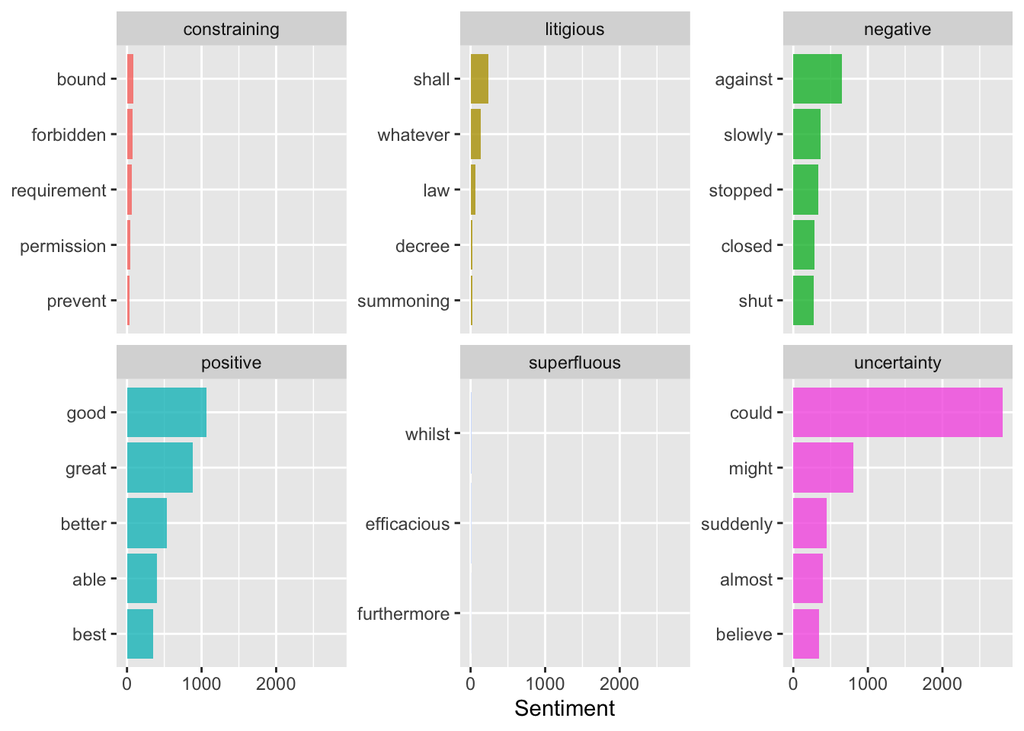

```r
loughran_word_counts %>%
        group_by(sentiment) %>%
        top_n(5) %>%
        ggplot(aes(reorder(word, n), n, fill = sentiment)) +
          geom_bar(alpha = 0.8, stat = "identity", show.legend = FALSE) +
          facet_wrap(~sentiment, scales = "free_y") +
          labs(y = "Sentiment", x = NULL) +
          coord_flip()
```

Now we can see the sentiment by book.

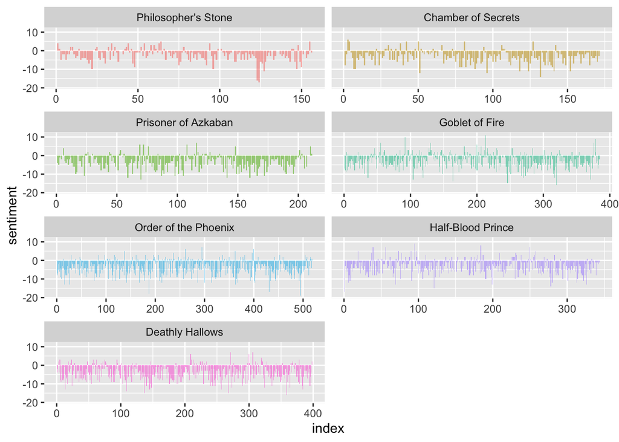

```r
series %>%
        group_by(book) %>%
        mutate(word_count = 1:n(),
               index = word_count %/% 500 + 1) %>%
        inner_join(get_sentiments("loughran")) %>%
        count(book, index = index , sentiment) %>%
        ungroup() %>%
        spread(sentiment, n, fill = 0) %>%
        mutate(sentiment = positive - negative,
               book = factor(book, levels = titles)) %>%
        ggplot(aes(index, sentiment, fill = book)) +
          geom_bar(alpha = 0.5, stat = "identity", show.legend = FALSE) +
          facet_wrap(~ book, ncol = 2, scales = "free_x")
```

## Conclusion:

Using the Loughram sentient was not the best lexicon to use. It looks to be focused on legal words, but it was good to see what it could do.

## Sources:

Silge, Julia, and David Robinson. 2017 “Text Mining with R” O’Reilly. 978-1-491-98165-8. https://www.tidytextmining.com https://github.com/dgrtwo/tidy-text-mining/find/master

Loughran, T. and McDonald, B. (2011), “When Is a Liability Not a Liability? Textual Analysis, Dictionaries, and 10-Ks.” The Journal of Finance, 66: 35-65. (Available at SSRN: http://ssrn.com/abstract=1331573.)

https://uc-r.github.io/sentiment_analysis

https://github.com/bradleyboehmke/harrypotter